# JP25__zadanie_domowe__modul_4_1

## **Analiza danych dotyczących Irysów**

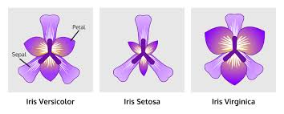

Zbiór danych zawiera informacje o trzech gatunkach irysów: Iris setosa, Iris versicolor, i Iris virginica.  
Dane obejmują pomiary czterech cech: długość i szerokość działki kielicha oraz długość i szerokość płatka.  
Każdy wiersz w zbiorze danych reprezentuje pojedynczy kwiat, a wartości pomiarów są podane w centymetrach.  
Zbiór składa się z 150 próbek, po 50 dla każdego gatunku, i jest szeroko stosowany jako podstawowy zbiór danych do testowania algorytmów klasyfikacji oraz w nauce o danych i uczeniu maszynowym.

Kolumny:

- **długość kielicha (sepal length)** - Długość kielicha w cm
- **szerokość kielicha (sepal width)** - Szerokość kielicha w cm
- **długość płatka (petal length)** - Długość płatka w cm
- **szerokość płatka (petal width)** - Szerokość płatka w cm
- **klasa (class)** - Klasa irysa (setosa, versicolor, virginica)

Tabela zawiera 15 losowych próbek danych dotyczących irysów.

|  | długość kielicha | szerokość kielicha | długość płatka | szerokość płatka | gatunek |
| --- | --- | --- | --- | --- | --- |
| 7 | 5.0 | 3.4 | 1.5 | 0.2 | Iris-setosa |
| 143 | 6.8 | 3.2 | 5.9 | 2.3 | Iris-virginica |
| 17 | 5.1 | 3.5 | 1.4 | 0.3 | Iris-setosa |
| 95 | 5.7 | 3.0 | 4.2 | 1.2 | Iris-versicolor |
| 87 | 6.3 | 2.3 | 4.4 | 1.3 | Iris-versicolor |
| 70 | 5.9 | 3.2 | 4.8 | 1.8 | Iris-versicolor |
| 53 | 5.5 | 2.3 | 4.0 | 1.3 | Iris-versicolor |
| 76 | 6.8 | 2.8 | 4.8 | 1.4 | Iris-versicolor |
| 36 | 5.5 | 3.5 | 1.3 | 0.2 | Iris-setosa |
| 128 | 6.4 | 2.8 | 5.6 | 2.1 | Iris-virginica |
| 129 | 7.2 | 3.0 | 5.8 | 1.6 | Iris-virginica |
| 63 | 6.1 | 2.9 | 4.7 | 1.4 | Iris-versicolor |
| 74 | 6.4 | 2.9 | 4.3 | 1.3 | Iris-versicolor |
| 8 | 4.4 | 2.9 | 1.4 | 0.2 | Iris-setosa |
| 91 | 6.1 | 3.0 | 4.6 | 1.4 | Iris-versicolor |

```
========== Informacje o zbiorze danych ==========
<class 'pandas.core.frame.DataFrame'>
RangeIndex: 150 entries, 0 to 149
Data columns (total 5 columns):
 #   Column              Non-Null Count  Dtype
---  ------              --------------  -----
 0   długość kielicha    150 non-null    float64
 1   szerokość kielicha  150 non-null    float64
 2   długość płatka      150 non-null    float64
 3   szerokość płatka    150 non-null    float64
 4   gatunek             150 non-null    object
dtypes: float64(4), object(1)
memory usage: 6.0+ KB

========== Ilość wystąpień gatunku ================
gatunek
Iris-setosa        50
Iris-versicolor    50
Iris-virginica     50

========== Unikalne wartości w kolumnach ==========
                    Liczba unikalnych wartości
długość kielicha                            35
szerokość kielicha                          23
długość płatka                              43
szerokość płatka                            22
gatunek                                      3

========== Duplikaty w zbiorze danych =============
     długość kielicha  szerokość kielicha  długość płatka  szerokość płatka  \
34                4.9                 3.1             1.5               0.1
37                4.9                 3.1             1.5               0.1
142               5.8                 2.7             5.1               1.9

            gatunek
34      Iris-setosa
37      Iris-setosa
142  Iris-virginica
```

**Wstępna analiza**

Dane zawierają 150 próbek, po 50 dla trzech gatunków. Jedna kolumna tekstowa i cztery numeryczne.  
Dane są kompletne, posortowane, bez brakujących wartości. Duplikaty nie wymagają ingerencji.  
Statystyki opisowe wskazują na zróżnicowanie cech między gatunkami, co sugeruje potencjał do skutecznej klasyfikacji.

|  | długość kielicha | szerokość kielicha | długość płatka | szerokość płatka |
| --- | --- | --- | --- | --- |
| count | 150.00 | 150.00 | 150.00 | 150.00 |
| mean | 5.84 | 3.05 | 3.76 | 1.20 |
| std | 0.83 | 0.43 | 1.76 | 0.76 |
| min | 4.30 | 2.00 | 1.00 | 0.10 |
| 25% | 5.10 | 2.80 | 1.60 | 0.30 |
| 50% | 5.80 | 3.00 | 4.35 | 1.30 |
| 75% | 6.40 | 3.30 | 5.10 | 1.80 |
| max | 7.90 | 4.40 | 6.90 | 2.50 |

```
Histogramy dla wszystkich Irysów
```

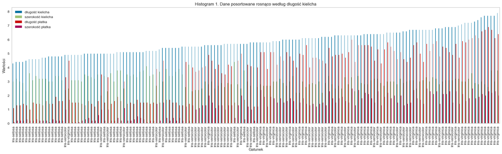

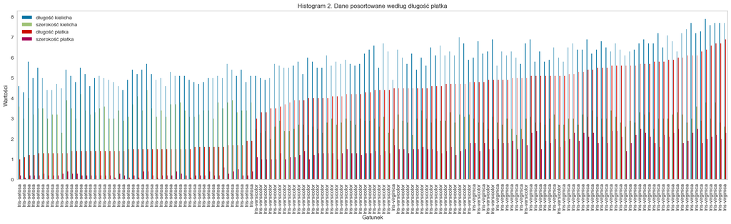

## **Analiza histogramów 1 i 2**

Gatunek Setosa należy do najmniejszych z analizowanej grupy. Jako jedyny posiada dużo krótsze płatki w odniesieniu do długości kielicha  
niż pozostałe gatunki. Najbardziej jednolitym i tożsamym parametrem dla poszczególnych gatunków jest długoś płatka która dla Setosa jest najmniejsza a dla Virginika największa.

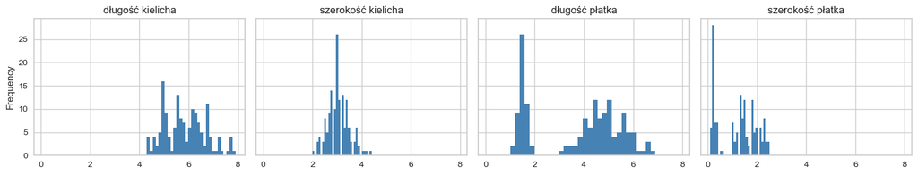

**Analiza Irysów razem**

Irysy ze zbioru mają kwiaty w rozmiarach:

- długość kielicha od 4,3 do 7,9 średnio 5,84 cm

- szerokość kielicha od 2 do 4,4 średnio 3.05 cm

- długość płatka od 1 do 6,9 średnio 3.76 cm

- szerokość płatka od 0,1 do 2,5 średnio 1.20 cm  
  Odchylenie standardowe na poziomie od 0,43 do 1,76, największe dla długości płatka.  
  Histogramy dla całego zbioru pokazują duże anomalia w rozmiarach Irysów  
  spowodowane rużnicami w budowie poszczegulnych gatunków

**Porównanie gatunków**

Iris-setosa średnio ma najkrótszy ale za to najszerszy kielich i ma najmniejsze odchylenie standardowe dla wymiarów płatka a szczegulnie dla szerokości.  
Iris-virginica ma największe kwiaty a przy tym największe odchylenie standardowe nie licząc szerokości kielicha.

|  | gatunek | długość kielicha min | długość kielicha mean | długość kielicha median | długość kielicha max | długość kielicha std | szerokość kielicha min | szerokość kielicha mean | szerokość kielicha median | szerokość kielicha max | szerokość kielicha std | długość płatka min | długość płatka mean | długość płatka median | długość płatka max | długość płatka std | szerokość płatka min | szerokość płatka mean | szerokość płatka median | szerokość płatka max | szerokość płatka std |
| --- | --- | --- | --- | --- | --- | --- | --- | --- | --- | --- | --- | --- | --- | --- | --- | --- | --- | --- | --- | --- | --- |
| 0 | Iris-setosa | 4.3 | 5.01 | 5.0 | 5.8 | 0.35 | 2.3 | 3.42 | 3.4 | 4.4 | 0.38 | 1.0 | 1.46 | 1.50 | 1.9 | 0.17 | 0.1 | 0.24 | 0.2 | 0.6 | 0.11 |
| 1 | Iris-versicolor | 4.9 | 5.94 | 5.9 | 7.0 | 0.52 | 2.0 | 2.77 | 2.8 | 3.4 | 0.31 | 3.0 | 4.26 | 4.35 | 5.1 | 0.47 | 1.0 | 1.33 | 1.3 | 1.8 | 0.20 |
| 2 | Iris-virginica | 4.9 | 6.59 | 6.5 | 7.9 | 0.64 | 2.2 | 2.97 | 3.0 | 3.8 | 0.32 | 4.5 | 5.55 | 5.55 | 6.9 | 0.55 | 1.4 | 2.03 | 2.0 | 2.5 | 0.27 |

**Cechy Iris-setosa**

```
--- Wartości unikatowe   ---
długość kielicha      15
szerokość kielicha    16
długość płatka         9
szerokość płatka       6
gatunek                1
dtype: int64
--- Statystyki opisowe ---
```

|  | długość kielicha | szerokość kielicha | długość płatka | szerokość płatka |
| --- | --- | --- | --- | --- |
| count | 50.00 | 50.00 | 50.00 | 50.00 |
| mean | 5.01 | 3.42 | 1.46 | 0.24 |
| std | 0.35 | 0.38 | 0.17 | 0.11 |
| min | 4.30 | 2.30 | 1.00 | 0.10 |
| 25% | 4.80 | 3.12 | 1.40 | 0.20 |
| 50% | 5.00 | 3.40 | 1.50 | 0.20 |
| 75% | 5.20 | 3.68 | 1.58 | 0.30 |
| max | 5.80 | 4.40 | 1.90 | 0.60 |

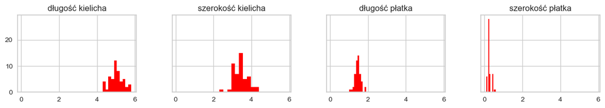

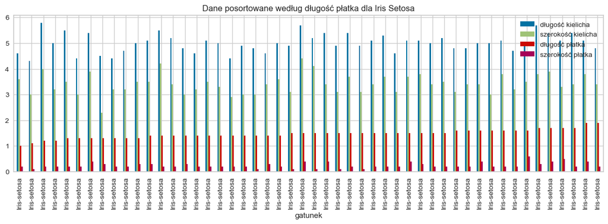

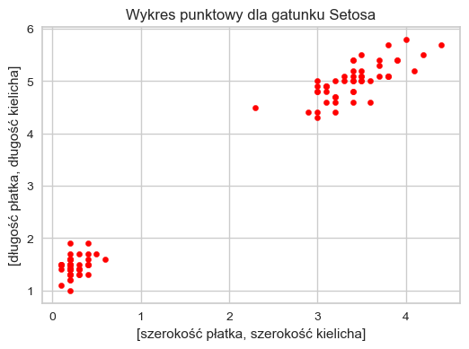

```
Koleracja dla Iris Setosa
```

|  | długość kielicha | szerokość kielicha | długość płatka | szerokość płatka |
| --- | --- | --- | --- | --- |
| długość kielicha | 1.00 | 0.75 | 0.26 | 0.28 |
| szerokość kielicha | 0.75 | 1.00 | 0.18 | 0.28 |
| długość płatka | 0.26 | 0.18 | 1.00 | 0.31 |
| szerokość płatka | 0.28 | 0.28 | 0.31 | 1.00 |

**Analiza Iris-setosa**

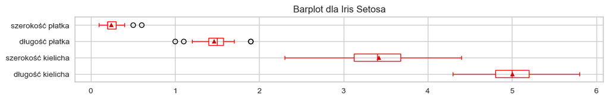

**Cechy Iris-versicolor**

```
--- Wartości unikatowe ---
długość kielicha      21
szerokość kielicha    14
długość płatka        19
szerokość płatka       9
gatunek                1
dtype: int64
--- Statystyki opisowe ---
```

|  | długość kielicha | szerokość kielicha | długość płatka | szerokość płatka |
| --- | --- | --- | --- | --- |
| count | 50.00 | 50.00 | 50.00 | 50.00 |
| mean | 5.94 | 2.77 | 4.26 | 1.33 |
| std | 0.52 | 0.31 | 0.47 | 0.20 |
| min | 4.90 | 2.00 | 3.00 | 1.00 |
| 25% | 5.60 | 2.52 | 4.00 | 1.20 |
| 50% | 5.90 | 2.80 | 4.35 | 1.30 |
| 75% | 6.30 | 3.00 | 4.60 | 1.50 |
| max | 7.00 | 3.40 | 5.10 | 1.80 |

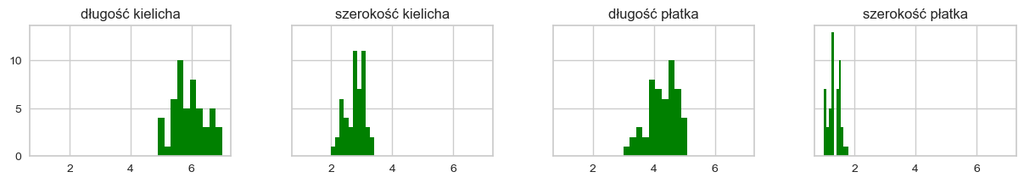

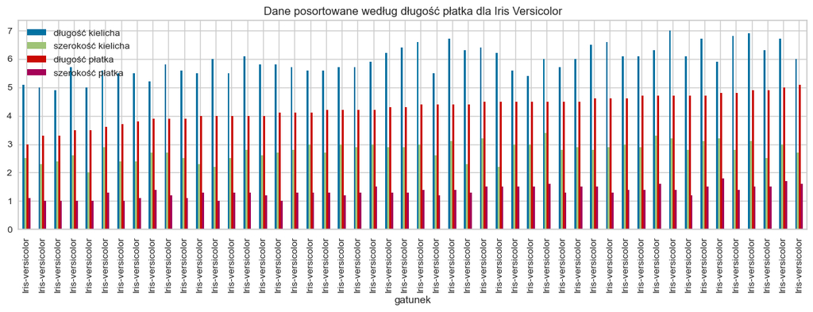

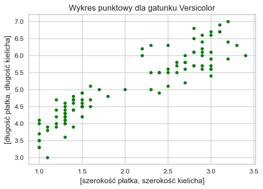

```
Koleracja dla Irys Versicolor
```

|  | długość kielicha | szerokość kielicha | długość płatka | szerokość płatka |
| --- | --- | --- | --- | --- |
| długość kielicha | 1.00 | 0.53 | 0.75 | 0.55 |
| szerokość kielicha | 0.53 | 1.00 | 0.56 | 0.66 |
| długość płatka | 0.75 | 0.56 | 1.00 | 0.79 |
| szerokość płatka | 0.55 | 0.66 | 0.79 | 1.00 |

**Analiza Iris-versicolor**

Kwiaty średnich rozmiarów z nieznaczną ilością danych odstających dla długości płatka.  
Odchylenie standardowe na poziomie od 0,52 dla długości kielicha do 0,20 dla szerokości płatka.  
Wysoka koleracja dodatnia w okolicy 0,75 dla par dł. płatka do dł kielicha i dł. platka do sz.płatka. Dla pozostałych par jest zbliżona do 0,55

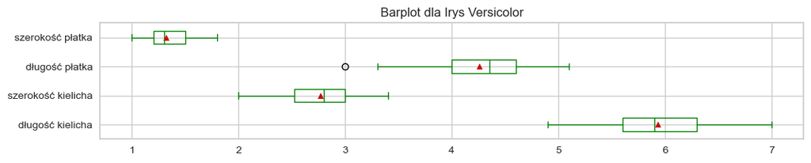

**Cechy Iris-virginica**

```
--- Unikalne wartości ---
długość kielicha      21
szerokość kielicha    13
długość płatka        20
szerokość płatka      12
gatunek                1
dtype: int64
---  Statystyki opisowe ---
```

|  | długość kielicha | szerokość kielicha | długość płatka | szerokość płatka |
| --- | --- | --- | --- | --- |
| count | 50.00 | 50.00 | 50.00 | 50.00 |
| mean | 6.59 | 2.97 | 5.55 | 2.03 |
| std | 0.64 | 0.32 | 0.55 | 0.27 |
| min | 4.90 | 2.20 | 4.50 | 1.40 |
| 25% | 6.22 | 2.80 | 5.10 | 1.80 |
| 50% | 6.50 | 3.00 | 5.55 | 2.00 |
| 75% | 6.90 | 3.18 | 5.88 | 2.30 |
| max | 7.90 | 3.80 | 6.90 | 2.50 |

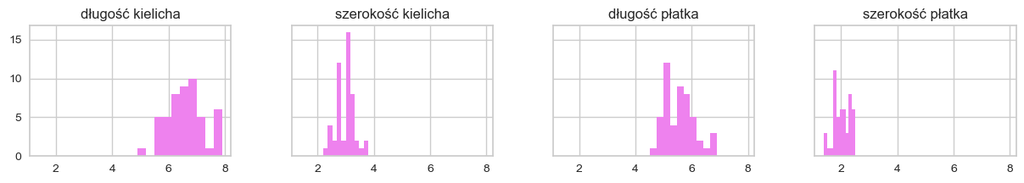

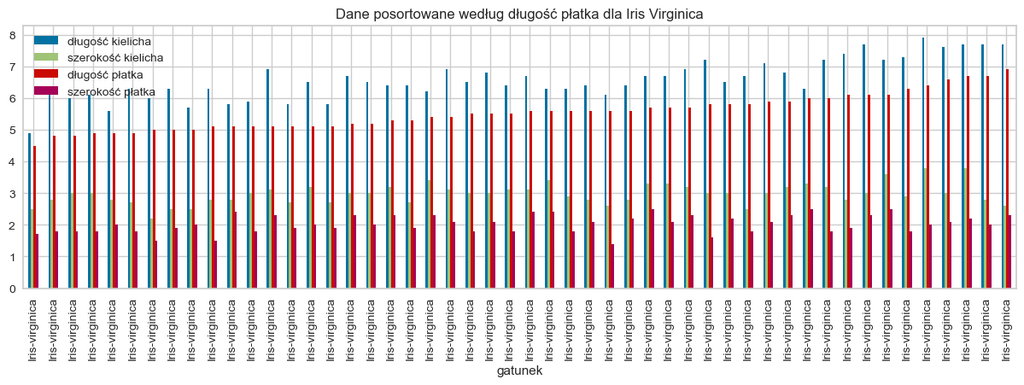

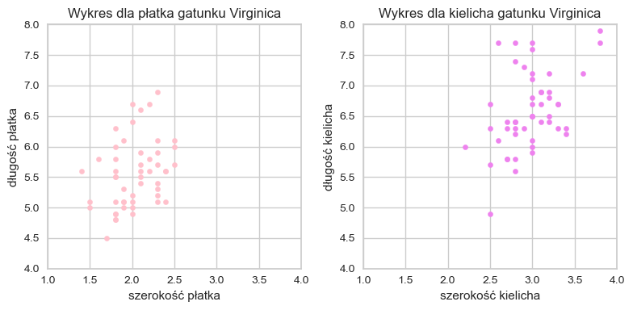

```
Koleracja dla Irys Virginica
```

|  | długość kielicha | szerokość kielicha | długość płatka | szerokość płatka |
| --- | --- | --- | --- | --- |
| długość kielicha | 1.00 | 0.46 | 0.86 | 0.28 |
| szerokość kielicha | 0.46 | 1.00 | 0.40 | 0.54 |
| długość płatka | 0.86 | 0.40 | 1.00 | 0.32 |
| szerokość płatka | 0.28 | 0.54 | 0.32 | 1.00 |

**Analiza Iris-virginica**

Kwiat regularny najwiękrzych rozmiarów z nieznaczną ilością danych odstających dla rozmiarów kielicha.  
Odchylenie standardowe na poziomie od 0,64 dla długości kielicha do 0,27 dla szerokości płatka.  
Wysoka koleracja dodatnia w okolicy 0,86 dla par dł. płatka do dł kielicha.  
Dla pozostałych par jest zbliżona od 0,55 aż do ok 0,30 dla szerokości płatka w stosunku do wymiarów kielicha.

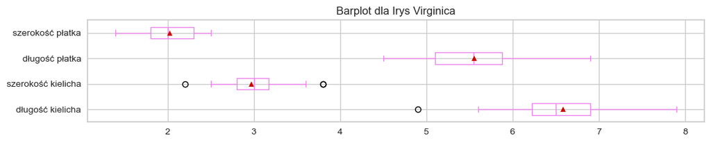

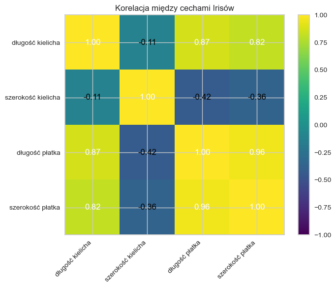

## **=== Wnioski końcowe ===**

Badane gatunki Irysów wykazują duże zróżnicowanie pod względem wymiaruw oraz proporcji elementów kwiatów.  
Najmniejszym gatunkiem jest Iris Setosa a największym Iris virginica.  
Cechą harakterystyczną odrużniającą gatunki jest długość płatka.  
Wysoką dodatnia koleracja dla jednych par i ujemną dla innych, wynika ze znacznych różnic w wymiarach kwiatów różnych gatunków.